# Données vectorielles

L’objectif principal de ce module est d’apprendre à lire, interpréter et visualiser des données vectorielles[^1]

À la fin de ce module vous saurez:

- Lire un *shapefile*, explorer ses métadonnées et interpréter sa géométrie.
- Lire une *geodatabase*, et explorer ses couches.
- Visualiser des données vectorielles de type point, ligne et polygone.
- Visualiser des données vectorielles par attribut.
- Visualiser plusieurs données vectorielles au sein d’une même figure.
- Transformer le système de coordonnées de référence de données vectorielles.

Vous utiliserez les librairies suivantes:

- `sf`
- `rgdal`
- `dplyr`
- `ggplot2`
- `ggpubr`

Vous apprendrez à utiliser les fonctions suivantes:

- `st_read()`, `st_write()`
- `st_geometry_type()`
- `st_crs()`
- `st_bbox()`
- `geom_sf`
- `filter()`
- `select()`
- `st_transform()`
- `ggarrange()`

Dans la section leçon, vous utiliserez deux ensembles de données vectorielles.

Le premier ensemble contient des données *shapefile* relatives au réseau de pistes cyclables de la ville de Montréal et aux accidents routiers impliquant des bicyclettes.

Le second ensemble consitutie une *géodatabase* contenant des données du Ministère de l’Éducation et de l’Enseignement Supérieur du Québec relatives aux établissements d’enseignement sur le territoire québécois.

## Leçon

Cette leçon est une introduction aux données spatiales sous `R`. Les trois premières sections porteront sur des données vectorielles en format *shapefile* puisque celles-ci sont couramment utilisées. La quatrième section vous familiarisera avec les données vectorielles en format *geodatabase* puisque celles-ci sont de plus en plus utilisées au sein de grandes organisations comme des ministères.

### Lire un *shapefile* et interpréter sa géométrie

Dans cette section, nous allons explorer des données vectorielles relatives au réseau de pistes cyclables de la ville de Montréal et aux accidents routiers impliquant des bicyclettes.

#### Importer les données

Téléchargez les [données sur le réseau de pistes cyclables](https://github.com/sci1031/sci1031/tree/master/Module4/data/Montreal_Velo.zip). Sauvegardez le dossier compressé (`zip`) dans votre répertoire de travail `Donnees` pour ce module, et dézippez-le. Le dossier Montreal_Velo comprend trois sous-dossiers:

- `accidents`
- `pistes`
- `terre`.

#### Lire les données

Pour lire des données vectorielles contenues dans un fichier *shapefile*, nous allons utiliser la librairie `sf`. Notez que la librairie `rgdal` se charge automatiquement lorsque `sf` se charge.

```r
library(sf)
```

Nous allons lire les trois *shapefiles* suivants :

- Des données vectorielles de type polygone représentant la frontière de notre zone d’étude, ici, l’île de Montréal.
- Des données vectorielles de type ligne représentant les pistes cyclables sur l’île de Montréal, et
- Des données vectorielles de type point représentant la position d’accidents impliquant des bicyclettes.

Dans un premier temps, nous allons ouvrir les données vectorielles de type polygone qui contiennent les limites terrestres de l’île de Montréal. Pour lire ces données nous utiliserons la fonction `st_read()` de la librarie `sf`. Pour utiliser `st_read()` nous devons spécifier le chemin menant au fichier *shapefile* à lire.

```r
chemin<-"D:/votrechemin/SCI1031/Module4/Donnees/"
nom_du_fichier <- paste(chemin, "/Montreal_Velo/terre/terre_shp.shp", sep = "")
limites_terrestres <- st_read(nom_du_fichier)
```

Nous allons maintenant lire les données vectorielles de type ligne, en utilisant encore la fonction `st_read()`.

```r
chemin <-"D:/votrechemin/SCI1031/Module4/Donnees/"
nom_du_fichier<- paste(chemin, "/Montreal_Velo/pistes/pistes_cyclables_type.shp", sep = "")
pistes_cyclables <- st_read(nom_du_fichier)
```

Finalement, nous allons lire les données vectorielles de type point, en utilisant toujours la fonction `st_read()`.

```r
chemin<-"D:/votrechemin/SCI1031/Module4/Donnees/"
nom_du_fichier<- paste(chemin, "/Montreal_Velo/accidents/accidents2018_Mtl_velo.shp", sep = "")
pistes_cyclables <- st_read(nom_du_fichier)
```

```r
accidents_velo <- st_read("Module4/data/Montreal_Velo/accidents/accidents2018_Mtl_velo.shp")
```

#### Explorer les métadonnées d’un *shapefile*

Les informations contenues dans un *shapefile* sont appelées des métadonnées. Nous sommes particulièrement intéressées aux métadonnées géospatiales.

Les métadonnées fondamentales d’un *shapefile* sont :

1. Le type de géométrie : le type de classes des données vectorielles téléchargées.
2. La projection : le système de coordonnées de référence utilisé pour représenter les données.
3. L’étendue spatiale : la superficie géographique couvrant les données vectorielles.

##### Le type de géogmétrie

Nous pouvons explorer chacune de ces métadonnées en utilisant des fonctions de la librairie `sf`. Le type de géométrie est obtenu par la fonction `st_geometry_type()`. Par exemple, pour les limites terrestres de la ville de Montréal, cette fonction nous donne:

```r
st_geometry_type(limites_terrestres)
```

```
##  [1] POLYGON POLYGON POLYGON POLYGON POLYGON POLYGON POLYGON POLYGON POLYGON
## [10] POLYGON POLYGON POLYGON POLYGON POLYGON POLYGON POLYGON POLYGON POLYGON
## [19] POLYGON POLYGON POLYGON POLYGON POLYGON POLYGON POLYGON POLYGON POLYGON
## [28] POLYGON POLYGON POLYGON POLYGON POLYGON POLYGON POLYGON POLYGON POLYGON
## [37] POLYGON POLYGON POLYGON POLYGON POLYGON POLYGON POLYGON POLYGON POLYGON
## [46] POLYGON POLYGON POLYGON POLYGON POLYGON POLYGON POLYGON POLYGON POLYGON
## [55] POLYGON POLYGON POLYGON POLYGON POLYGON POLYGON POLYGON POLYGON POLYGON
## [64] POLYGON POLYGON POLYGON POLYGON POLYGON POLYGON POLYGON POLYGON POLYGON
## 18 Levels: GEOMETRY POINT LINESTRING POLYGON MULTIPOINT ... TRIANGLE
```

Nous avons ainsi la confirmation que ces données vectorielles correspondent à des polygones (plus exactement, 72 polygones). Les 18 niveaux donnés en dessous constituent une liste des classes possibles de géométrie.

En comparaison, pour les données de type ligne et de type point nous obtenons plutôt :

```r
st_geometry_type(pistes_cyclables)
```

```
##    [1] MULTILINESTRING MULTILINESTRING MULTILINESTRING MULTILINESTRING
##    [5] MULTILINESTRING MULTILINESTRING MULTILINESTRING MULTILINESTRING
##    [9] MULTILINESTRING MULTILINESTRING MULTILINESTRING MULTILINESTRING
##   [13] MULTILINESTRING MULTILINESTRING MULTILINESTRING MULTILINESTRING
##   [17] MULTILINESTRING MULTILINESTRING MULTILINESTRING MULTILINESTRING
##   [21] MULTILINESTRING MULTILINESTRING MULTILINESTRING MULTILINESTRING
##   [25] MULTILINESTRING MULTILINESTRING MULTILINESTRING MULTILINESTRING
##   [29] MULTILINESTRING MULTILINESTRING MULTILINESTRING MULTILINESTRING
##   [33] MULTILINESTRING MULTILINESTRING MULTILINESTRING MULTILINESTRING
##   [37] MULTILINESTRING MULTILINESTRING MULTILINESTRING MULTILINESTRING
##   [41] MULTILINESTRING MULTILINESTRING MULTILINESTRING MULTILINESTRING
##   [45] MULTILINESTRING MULTILINESTRING MULTILINESTRING MULTILINESTRING
##   [49] MULTILINESTRING MULTILINESTRING MULTILINESTRING MULTILINESTRING
##   [53] MULTILINESTRING MULTILINESTRING MULTILINESTRING MULTILINESTRING
##   [57] MULTILINESTRING MULTILINESTRING MULTILINESTRING MULTILINESTRING
```

[output cut: 1585 more lines]

```r
st_geometry_type(accidents_velo)
```

```
##   [1] POINT POINT POINT POINT POINT POINT POINT POINT POINT POINT POINT POINT
##  [13] POINT POINT POINT POINT POINT POINT POINT POINT POINT POINT POINT POINT
##  [25] POINT POINT POINT POINT POINT POINT POINT POINT POINT POINT POINT POINT
##  [37] POINT POINT POINT POINT POINT POINT POINT POINT POINT POINT POINT POINT
##  [49] POINT POINT POINT POINT POINT POINT POINT POINT POINT POINT POINT POINT
##  [61] POINT POINT POINT POINT POINT POINT POINT POINT POINT POINT POINT POINT
##  [73] POINT POINT POINT POINT POINT POINT POINT POINT POINT POINT POINT POINT
##  [85] POINT POINT POINT POINT POINT POINT POINT POINT POINT POINT POINT POINT
##  [97] POINT POINT POINT POINT POINT POINT POINT POINT POINT POINT POINT POINT
## [109] POINT POINT POINT POINT POINT POINT POINT POINT POINT POINT POINT POINT
## [121] POINT POINT POINT POINT POINT POINT POINT POINT POINT POINT POINT POINT
## [133] POINT POINT POINT POINT POINT POINT POINT POINT POINT POINT POINT POINT
## [145] POINT POINT POINT POINT POINT POINT POINT POINT POINT POINT POINT POINT
## [157] POINT POINT POINT POINT POINT POINT POINT POINT POINT POINT POINT POINT
## [169] POINT POINT POINT POINT POINT POINT POINT POINT POINT POINT POINT POINT
```

[output cut: 53 more lines]

Vous remarquez alors que les pistes cyclables sont composées de nombreuses multilignes. Une multiligne étant elle-même un ensemble de lignes. Quant aux accidents de vélo, ce sont des points qui désignent la position précise des accidents. On en compte 796 en 2018.

##### La projection

Vérifions maintenant la projection des *shapefiles* en utilisant la fonction `st_crs()` de la librarie `sf`:

```r
st_crs(limites_terrestres)
```

```
## Coordinate Reference System:
##   User input: NAD83 / MTM zone 8
##   wkt:
## PROJCRS["NAD83 / MTM zone 8",
##     BASEGEOGCRS["NAD83",
##         DATUM["North American Datum 1983",
##             ELLIPSOID["GRS 1980",6378137,298.257222101,
##                 LENGTHUNIT["metre",1]]],
##         PRIMEM["Greenwich",0,
##             ANGLEUNIT["degree",0.0174532925199433]],
##         ID["EPSG",4269]],
##     CONVERSION["MTM zone 8",
##         METHOD["Transverse Mercator",
##             ID["EPSG",9807]],
##         PARAMETER["Latitude of natural origin",0,
##             ANGLEUNIT["degree",0.0174532925199433],
##             ID["EPSG",8801]],
##         PARAMETER["Longitude of natural origin",-73.5,
##             ANGLEUNIT["degree",0.0174532925199433],
##             ID["EPSG",8802]],
##         PARAMETER["Scale factor at natural origin",0.9999,
##             SCALEUNIT["unity",1],
##             ID["EPSG",8805]],
##         PARAMETER["False easting",304800,
##             LENGTHUNIT["metre",1],
##             ID["EPSG",8806]],
##         PARAMETER["False northing",0,
##             LENGTHUNIT["metre",1],
##             ID["EPSG",8807]]],
##     CS[Cartesian,2],
##         AXIS["easting (E(X))",east,
##             ORDER[1],
##             LENGTHUNIT["metre",1]],
##         AXIS["northing (N(Y))",north,
##             ORDER[2],
##             LENGTHUNIT["metre",1]],
##     USAGE[
##         SCOPE["unknown"],
##         AREA["Canada - Quebec and Ontario - 75Â°W to 72Â°W"],
##         BBOX[44.98,-75,62.53,-72]],
##     ID["EPSG",32188]]
```

```r
st_crs(pistes_cyclables)
```

```
## Coordinate Reference System:
##   User input: Transverse_Mercator
##   wkt:
## PROJCRS["Transverse_Mercator",
##     BASEGEOGCRS["NAD83",
##         DATUM["North American Datum 1983",
##             ELLIPSOID["GRS 1980",6378137,298.257222101,
##                 LENGTHUNIT["metre",1]],
##             ID["EPSG",6269]],
##         PRIMEM["Greenwich",0,
##             ANGLEUNIT["Degree",0.0174532925199433]]],
##     CONVERSION["unnamed",
##         METHOD["Transverse Mercator",
##             ID["EPSG",9807]],
##         PARAMETER["Latitude of natural origin",0,
##             ANGLEUNIT["Degree",0.0174532925199433],
##             ID["EPSG",8801]],
##         PARAMETER["Longitude of natural origin",-73.5,
##             ANGLEUNIT["Degree",0.0174532925199433],
##             ID["EPSG",8802]],
##         PARAMETER["Scale factor at natural origin",0.9999,
##             SCALEUNIT["unity",1],
##             ID["EPSG",8805]],
##         PARAMETER["False easting",304800,
##             LENGTHUNIT["metre",1],
##             ID["EPSG",8806]],
##         PARAMETER["False northing",0,
##             LENGTHUNIT["metre",1],
##             ID["EPSG",8807]]],
##     CS[Cartesian,2],
##         AXIS["(E)",east,
##             ORDER[1],
##             LENGTHUNIT["metre",1,
##                 ID["EPSG",9001]]],
##         AXIS["(N)",north,
##             ORDER[2],
##             LENGTHUNIT["metre",1,
##                 ID["EPSG",9001]]]]
```

```r
st_crs(accidents_velo)
```

```
## Coordinate Reference System:
##   User input: Transverse_Mercator
##   wkt:
## PROJCRS["Transverse_Mercator",
##     BASEGEOGCRS["NAD83",
##         DATUM["North American Datum 1983",
##             ELLIPSOID["GRS 1980",6378137,298.257222101,
##                 LENGTHUNIT["metre",1]],
##             ID["EPSG",6269]],
##         PRIMEM["Greenwich",0,
##             ANGLEUNIT["Degree",0.0174532925199433]]],
##     CONVERSION["unnamed",
##         METHOD["Transverse Mercator",
##             ID["EPSG",9807]],
##         PARAMETER["Latitude of natural origin",0,
##             ANGLEUNIT["Degree",0.0174532925199433],
##             ID["EPSG",8801]],
##         PARAMETER["Longitude of natural origin",-73.5,
##             ANGLEUNIT["Degree",0.0174532925199433],
##             ID["EPSG",8802]],
##         PARAMETER["Scale factor at natural origin",0.9999,
##             SCALEUNIT["unity",1],
##             ID["EPSG",8805]],
##         PARAMETER["False easting",304800,
##             LENGTHUNIT["metre",1],
##             ID["EPSG",8806]],
##         PARAMETER["False northing",0,
##             LENGTHUNIT["metre",1],
##             ID["EPSG",8807]]],
##     CS[Cartesian,2],
##         AXIS["(E)",east,
##             ORDER[1],
##             LENGTHUNIT["metre",1,
##                 ID["EPSG",9001]]],
##         AXIS["(N)",north,
##             ORDER[2],
##             LENGTHUNIT["metre",1,
##                 ID["EPSG",9001]]]]
```

##### L’étendue spatiale

Pour connaître l’étendue spatiale des *shapefiles*, nous utilisons la fonction `st_bbox()` de la librairie `sf` :

```r
st_bbox(limites_terrestres)
```

```
##      xmin      ymin      xmax      ymax
##  267517.3 5029231.9  306669.4 5062642.4
```

```r
st_bbox(pistes_cyclables)
```

```
##      xmin      ymin      xmax      ymax
##  267983.7 5029291.0  306349.2 5062582.4
```

```r
st_bbox(accidents_velo)
```

```
##      xmin      ymin      xmax      ymax
##  269488.9 5029751.7  305368.0 5059058.4
```

L’étendue spatiale d’un *shapefile* ou d’un objet spatial dans `R` représente les limites géographiques des données, ou la localisation des données les plus au sud, nord, est et ouest.

##### Les attributs

Finalement, nous pouvons visualiser toutes les métadonnées et les attributs d’un *shapefile* simplement en écrivant son nom dans la console `R`:

```r
limites_terrestres
```

```
## Simple feature collection with 72 features and 1 field
## geometry type:  POLYGON
## dimension:      XY
## bbox:           xmin: 267517.3 ymin: 5029232 xmax: 306669.4 ymax: 5062642
## projected CRS:  NAD83 / MTM zone 8
## First 10 features:
##    DefaultAtt                       geometry
## 1        <NA> POLYGON ((299607.6 5038364,...
## 2        <NA> POLYGON ((301349.7 5036978,...
## 3        <NA> POLYGON ((300403.5 5038997,...
## 4        <NA> POLYGON ((300743.9 5039496,...
## 5        <NA> POLYGON ((302032.4 5043372,...
## 6        <NA> POLYGON ((302299.3 5043145,...
## 7        <NA> POLYGON ((302508.4 5040978,...
## 8        <NA> POLYGON ((304719.4 5062024,...
## 9        <NA> POLYGON ((304926.9 5062499,...
## 10       <NA> POLYGON ((305395.9 5062622,...
```

```r
pistes_cyclables
```

```
## Simple feature collection with 6395 features and 1 field
## geometry type:  MULTILINESTRING
## dimension:      XY
## bbox:           xmin: 267983.7 ymin: 5029291 xmax: 306349.2 ymax: 5062582
## projected CRS:  Transverse_Mercator
## First 10 features:
##                        TYPE_VOIE                       geometry
## 1         Piste cyclable sur rue MULTILINESTRING ((297751.6 ...
## 2  Piste cyclable en site propre MULTILINESTRING ((305049.6 ...
## 3              Chaussée désignée MULTILINESTRING ((299076 50...
## 4                 Bande cyclable MULTILINESTRING ((287779.1 ...
## 5  Piste cyclable en site propre MULTILINESTRING ((300752.3 ...
## 6  Piste cyclable en site propre MULTILINESTRING ((300953.3 ...
## 7  Piste cyclable en site propre MULTILINESTRING ((299010.2 ...
## 8              Chaussée désignée MULTILINESTRING ((276414.9 ...
## 9  Piste cyclable en site propre MULTILINESTRING ((293077.3 ...
## 10 Piste cyclable en site propre MULTILINESTRING ((304787.1 ...
```

```r
accidents_velo
```

```
## Simple feature collection with 796 features and 1 field
## geometry type:  POINT
## dimension:      XY
## bbox:           xmin: 269488.9 ymin: 5029752 xmax: 305368 ymax: 5059058
## projected CRS:  Transverse_Mercator
## First 10 features:
##    FID                 geometry
## 1    0 POINT (279672.9 5041015)
## 2    1 POINT (277292.4 5039169)
## 3    2 POINT (275581.5 5036314)
## 4    3 POINT (274728.2 5035946)
## 5    4 POINT (283935.4 5040875)
## 6    5 POINT (280442.1 5039871)
## 7    6 POINT (279625.7 5040700)
## 8    7 POINT (277733.7 5038853)
## 9    8 POINT (276486.6 5038090)
## 10   9   POINT (278357 5040125)
```

### Visualisation de *shapefiles* sous R

#### Visualisation avec la fonction `R` `ggplot`

Vous allez maintenant apprendre à visualer des données *shapefile* en utilisant la fonction `ggplot()` de la librairie `ggplot2`.

```r
library(ggplot2)
```

Dans un premier temps, visualisons les limites terrestres de l’île de Montréal (Fig @ref(fig:plot-terre)).

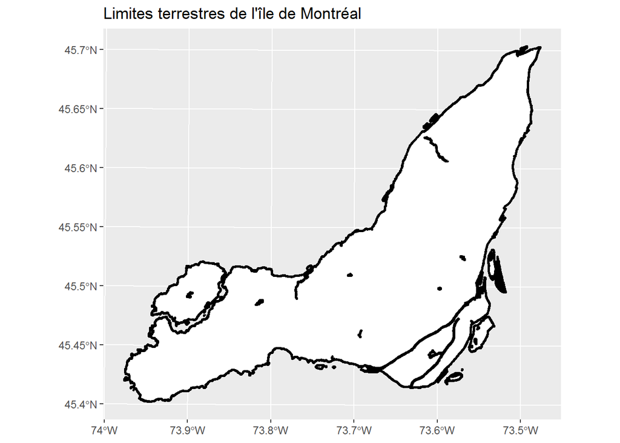

Limites terrestres de l’île de Montréal

```r
ggplot() +
geom_sf(data = limites_terrestres, size = 1, color = "black", fill = "white") +
ggtitle("Limites terrestres de l'île de Montréal")
```

La fonction `geom_sf()` permet de faire des représentations simples d’objets vectoriels de géométrie de type point, ligne et polygone. Cette fonction peut prendre plusieurs arguments[^2]. Les arguments utilisés ici sont:

La fonction ggtitle permet d’ajouter un titre à la figure générée.

Remarquez que chaque fonction est écrite sur sa propre ligne, pour faciliter la lecture des lignes de commande, et que chaque fonction qui s’ajoute à `ggplot()` est précédée par le signe plus `+`.

Dans un deuxième temps, visualisons les pistes cyclables (Fig @ref(fig:plot-velo)).

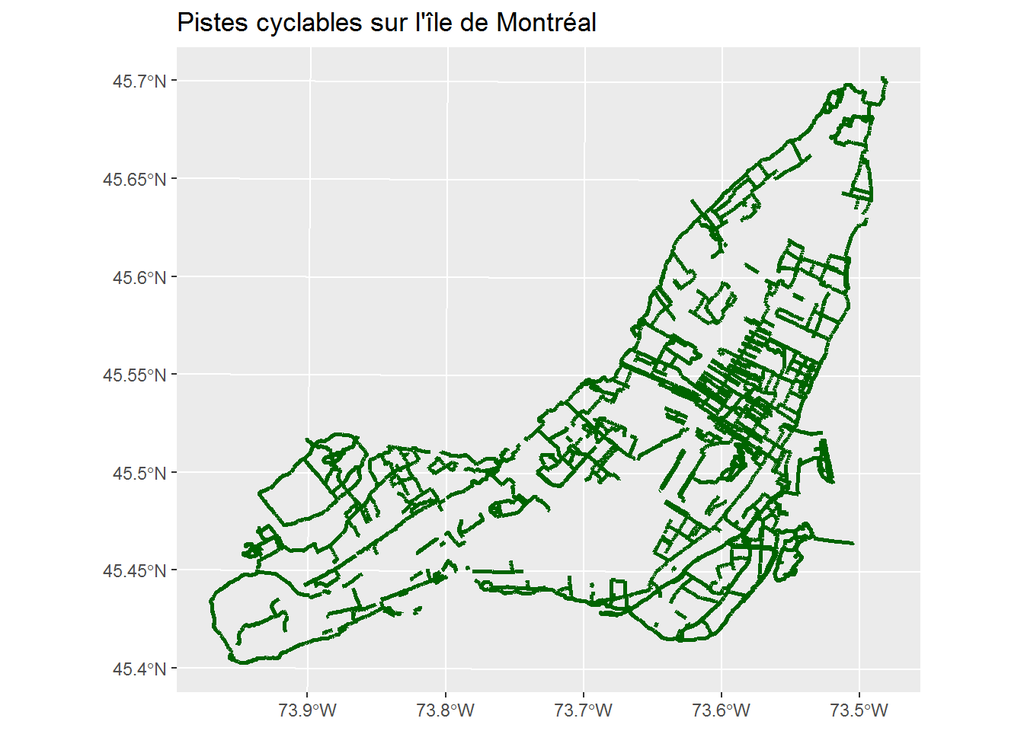

Pistes cyclables sur l’île de Montréal

```r
ggplot() +
geom_sf(data = pistes_cyclables, size = 1, color = "darkgreen") +
ggtitle("Pistes cyclables sur l'île de Montréal")
```

Pour visualiser des lignes, nous n’avons évidemment pas besoin de définir l’argument `fill` car nous visualisons des lignes plutôt qu’une surface. Vous remarquerez que les lignes, cette fois, sont vertes foncées (`darkgreen`).

Il existe 657 couleurs prédéfinies dans `R`. Taper la commande `colors()` dans votre console `R` pour voir afficher le nom des couleurs. Celles-sont sont listées par ordre alphabétique sauf pour la première couleur, qui est le blanc (`white`). Ainsi, vous pouvez utiliser une couleur en assignant son nom ou son numéro. Pour produire la figure précédente, `color = "darkgreen"` aurait pu être remplacé par `color = colors()[81]`. Essayez pour voir.